## set up the working directory for the task

```r
folder = 'C:/Users/אחיעד/Desktop/data science/ass3/question2'
setwd(folder)

#Or for all chuncks in this Rmarkdown:
knitr::opts_knit$set(root.dir = folder)
```

## install and import the packages that we need for this task.

```r
#install.packages("twitteR")
#install.packages("tm")
#install.packages("httr")
#install.packages("igraph")
library(igraph)
library(twitteR)
library(tm)
library(httr)
source("my_credentials.R")
```

## Here we set up the OAuth credentials for a twitteR session:

```r
achiad_credentials <- setup_twitter_oauth(consumer_key, consumer_secret, access_token, access_secret)
```

```
## [1] "Using direct authentication"
```

# the data we collected is the users that tweets on the champions league. and all the details that tweeter save for his users. we collect the datain temp_df data frame.

## Here we get the 500 last tweets that people twits on the champions league, after we get all this twits we convert them to data frame, and take the usernames that twited those twits. once we have this usernames we lookup for the users for those usernames and save them in dataframe for future use.

```r
searchRes <- searchTwitter("#champions_league", n=500)
champions_tag <- twListToDF(searchRes) # converting to df
usernames <- champions_tag$screenName
temp_df <- twListToDF(lookupUsers(usernames))
```

## Here we set up two empty vectors.

```r
  user1_edge <- c()
  user2_edge <- c()
```

# now we will declare the nodes and edges in the graph: the nodes are the users that we collected, it will be an edge between two users if the twits that they twited was in the same language.

## Now after we get all the users in dataframe we iterate over all the users, and if we found another user that tweets on the champions league in the same language like the first user we add them to the vectors, the first user to the first vector and the second user to the second vector.

```r
for(i in 1:nrow(temp_df)){
  for(j in 1:nrow(temp_df)){
    user1 <- temp_df[i,]
    user2 <- temp_df[j,]
    if((user1$screenName != user2$screenName) && (user1$lang == user2$lang)){
      user1_edge<-c(user1_edge , user1$screenName)
      user2_edge<-c(user2_edge , user2$screenName)
    }
  }
}
```

## Now we create a csv file from this two vectors in order to create a graph from this csv file like we did in the first task on the gray anatomy file.

```r
res <- cbind(from= user1_edge,to=user2_edge)
write.csv(res,file="C:/Users/אחיעד/Desktop/data science/ass3/question2/ga_edgelist.csv",row.names = F)
```

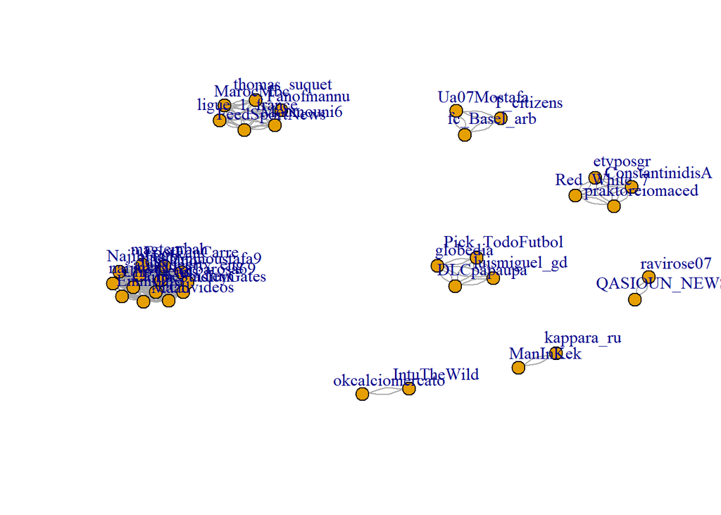

```r
ga.data <- read.csv('ga_edgelist.csv', header = T)
g <- graph.data.frame(ga.data,directed = F)
degr.score <- degree(g)
V(g)$size <- degr.score * 4 # multiply by 2 for scale

plot(g, vertex.size=5, vertex.label=V(g)$name, vertex.label.dist=2, asp=FALSE)
```

## compute the betweeness of each node in the graph. We use the betweeness algorhitm with igraph package on the g graph. the graph is not directed and he has no weights on the edges. The nobigint is set to TRUE in order to not use big integers in the calculation because This is only required for lattice-like graphs that have very many shortest paths between a pair of vertices.We also set the normalized parameter to false because we dont want to normalize the results.

# The highest betweeness that measured is for the user: all the users have betweeness of 0 because we built the graph in a way that in each component all the nodes are equal in the betweeness measure because all the nodes in each component are connect to each other node.

```r
betweenness(g, v = V(g), directed = FALSE, weights = NULL,
  nobigint = TRUE, normalized = FALSE)
```

```
##         3dueUno       Moumouni6 praktoreiomaced   thomas_suquet
##               0               0               0               0
##    QASIOUN_NEWS  eslammoustafa9   Cairo_Stadium     IntuTheWild
##               0               0               0               0
##  ligue_1_france    FootFanCarre   luismiguel_gd       naijapary
##               0               0               0               0
##      Fanofmannu      kappara_ru    fc_Basel_arb Pick_TodoFutbol
##               0               0               0               0
##            Maad alghadeertv_eng     Ua07Mostafa        Emmylite
##               0               0               0               0
##      NajibHaiby okcalciomercato        etyposgr      ClipTrends
##               0               0               0               0
## ConstantinidisA     barbarosa69     Red_White_7        MarocMbc
##               0               0               0               0
##       UCLvideos      ravirose07        globedia   FeedSportNews
##               0               0               0               0
##        ManInKek       magtembah ThePaisleyGates      DLCpapaupa
##               0               0               0               0
##      T_citizens
##               0
```

## compute the closeness of each node in the giant component of the graph. We use the closeness algorhitm with igraph package on the g graph. the graph has no weights on the edges. We also set the normalized parameter to false because we dont want to normalize the results.

# The highest closeness that measured is for the user: All the user in the same component has the same closeness value because each node connect to all the other nodes in the component. so all the nodes in the giant component has the best closeness value from the definition of closeness.

```r
closeness(g, vids = V(g),   weights = NULL, normalized = FALSE)
```

```
##         3dueUno       Moumouni6 praktoreiomaced   thomas_suquet
##    0.0011574074    0.0008680556    0.0008169935    0.0008680556
##    QASIOUN_NEWS  eslammoustafa9   Cairo_Stadium     IntuTheWild
##    0.0007716049    0.0011574074    0.0011574074    0.0007716049
##  ligue_1_france    FootFanCarre   luismiguel_gd       naijapary
##    0.0008680556    0.0011574074    0.0008169935    0.0011574074
##      Fanofmannu      kappara_ru    fc_Basel_arb Pick_TodoFutbol
##    0.0008680556    0.0007716049    0.0007936508    0.0008169935
##            Maad alghadeertv_eng     Ua07Mostafa        Emmylite
##    0.0011574074    0.0011574074    0.0007936508    0.0011574074
##      NajibHaiby okcalciomercato        etyposgr      ClipTrends
##    0.0011574074    0.0007716049    0.0008169935    0.0011574074
## ConstantinidisA     barbarosa69     Red_White_7        MarocMbc
##    0.0008169935    0.0011574074    0.0008169935    0.0008680556
##       UCLvideos      ravirose07        globedia   FeedSportNews
##    0.0011574074    0.0007716049    0.0008169935    0.0008680556
##        ManInKek       magtembah ThePaisleyGates      DLCpapaupa
##    0.0007716049    0.0011574074    0.0011574074    0.0008169935
##      T_citizens
##    0.0007936508
```

## compute the iii. Eigenvector of each node in the giant component of the graph. We use the eigen_centrality algorhitm with igraph package on the g graph. the graph is not directed and he has no weights on the edges. scale is Logical scalar, whether to scale the result to have a maximum score of one (we want to see which actor has the maximal Eigenvector. the options is A named list, to override some ARPACK options.

# The highest Eigenvector that measured is for the user : All the user in the same component has the same Eigenvector value because each node connect to all the other nodes in the component. so all the nodes in the giant component has the best Eigenvector value from the definition of Eigenvector.

```r
eigen_centrality(g, directed = FALSE, scale = TRUE, weights = NULL,
  options = arpack_defaults)
```

```
## $vector
##         3dueUno       Moumouni6 praktoreiomaced   thomas_suquet
##               1               0               0               0
##    QASIOUN_NEWS  eslammoustafa9   Cairo_Stadium     IntuTheWild
##               0               1               1               0
##  ligue_1_france    FootFanCarre   luismiguel_gd       naijapary
##               0               1               0               1
##      Fanofmannu      kappara_ru    fc_Basel_arb Pick_TodoFutbol
##               0               0               0               0
##            Maad alghadeertv_eng     Ua07Mostafa        Emmylite
##               1               1               0               1
##      NajibHaiby okcalciomercato        etyposgr      ClipTrends
##               1               0               0               1
## ConstantinidisA     barbarosa69     Red_White_7        MarocMbc
##               0               1               0               0
##       UCLvideos      ravirose07        globedia   FeedSportNews
##               1               0               0               0
##        ManInKek       magtembah ThePaisleyGates      DLCpapaupa
##               0               1               1               0
##      T_citizens
##               0
##
## $value
## [1] 26
##
## $options
## $options$bmat
## [1] "I"
##
## $options$n
## [1] 37
##
## $options$which
## [1] "LA"
##
## $options$nev
## [1] 1
##
## $options$tol
## [1] 0
```

[output cut: 30 more lines]

[output not shown]

## We devide the communities of the users graph using the edge.betweenness.community algorhitm of the igraph package. This is a divisive method that works on undirected unweighted graphs. It is based on calculating for each edge its betweeness - the number of shortest path going through this edge.It then iteratively removes the edge with the highest betweeness score, until reaching some threshold.The remaining connected vertices are the communities (clusters).